# EP08-respuesta-equipo-4.Rmd

# Revisión de las condiciones

Según el material de clases, una ANOVA de una vía para muestras independientes requiere una variable numérica, muestras aleatorias e independientes, normalidad aproximada y homogeneidad de varianzas.

La independencia se aborda seleccionando una única vivienda por observación. La normalidad se revisa mediante gráficos Q-Q y la homogeneidad se evalúa comparando la mayor y la menor varianza muestral. El criterio indicado en las lecturas considera razonable una razón no superior a 1,5.

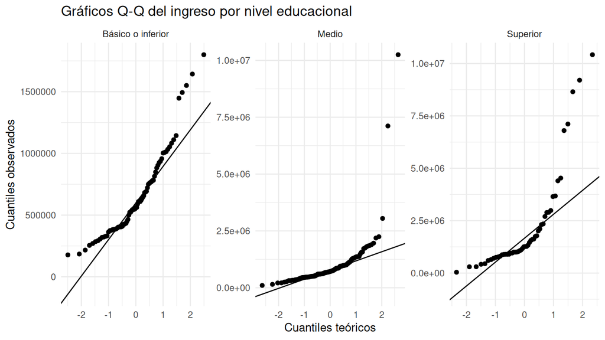

```r
ggplot(
  muestra,
  aes(sample = ytotcorh)
) +
  stat_qq() +
  stat_qq_line() +
  facet_wrap(~ nivel, scales = "free") +
  labs(
    title = "Gráficos Q-Q del ingreso por nivel educacional",
    x = "Cuantiles teóricos",
    y = "Cuantiles observados"
  ) +
  theme_minimal()
```

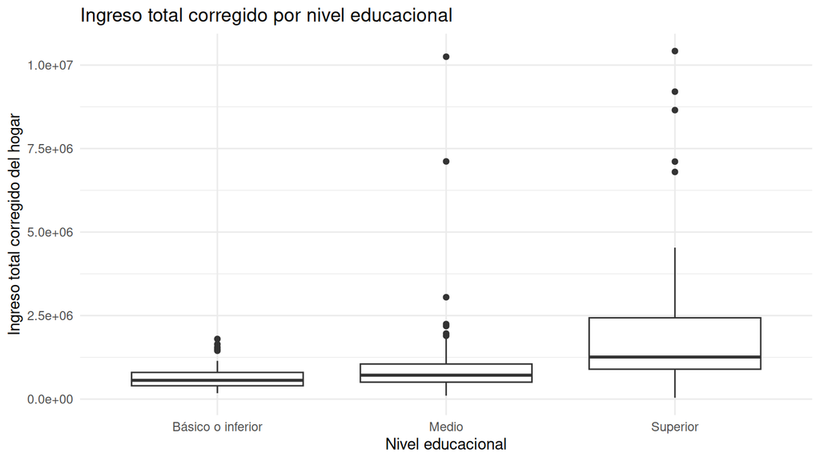

```r
ggplot(
  muestra,
  aes(x = nivel, y = ytotcorh)
) +
  geom_boxplot() +
  labs(
    title = "Ingreso total corregido por nivel educacional",
    x = "Nivel educacional",
    y = "Ingreso total corregido del hogar"
  ) +
  theme_minimal()
```

```r
razon_varianzas <- max(resumen$varianza) /
  min(resumen$varianza)

cat(
  "La razón entre la mayor y la menor varianza muestral es **",
  round(razon_varianzas, 2),
  "**. ",
  sep = ""
)
```

La razón entre la mayor y la menor varianza muestral es **45.42**.

```r
if (razon_varianzas <= 1.5) {
  cat(
    "De acuerdo con el criterio presentado en las lecturas, ",
    "la condición de homogeneidad de varianzas puede considerarse razonable."
  )
} else {
  cat(
    "Este valor supera 1,5, por lo que la condición de homogeneidad ",
    "de varianzas no se cumple adecuadamente."
  )
}
```

Este valor supera 1,5, por lo que la condición de homogeneidad de varianzas no se cumple adecuadamente.

Los gráficos deben interpretarse junto con este resultado. Si los puntos se apartan notoriamente de la recta teórica, se observa asimetría o aparecen valores extremos, no resulta conveniente depender exclusivamente de la distribución $F$ teórica. Por esta razón se aplica el procedimiento bootstrap solicitado.

# Prueba ómnibus mediante bootstrap

Bajo $H_0$, los tres grupos deben tener la misma media. Para representar esta situación, se centra cada grupo en la media total y luego se remuestrea con reemplazo dentro de cada grupo, conservando sus tamaños originales.

Se realizan 9.999 remuestras. En cada una se calcula el estadístico $F$. El valor p corresponde a la proporción de estadísticos bootstrap iguales o mayores que el observado.

```r
estadistico_F <- function(y, grupo) {
  summary(aov(y ~ grupo))[[1]][1, "F value"]
}

pares <- combn(levels(muestra$nivel), 2)

diferencias_medias <- function(y, grupo) {
  apply(
    pares,
    2,
    function(par) {
      mean(y[grupo == par[1]]) -
        mean(y[grupo == par[2]])
    }
  )
}

y <- muestra$ytotcorh
grupo <- muestra$nivel

F_observado <- estadistico_F(y, grupo)
diferencias_observadas <- diferencias_medias(y, grupo)

media_total <- mean(y)

datos_bajo_H0 <- lapply(
  levels(grupo),
  function(nivel) {
    x <- y[grupo == nivel]
    x - mean(x) + media_total
  }
)

names(datos_bajo_H0) <- levels(grupo)
tamanos <- table(grupo)

B <- 9999
F_boot <- numeric(B)

# Aquí se guardan también las diferencias entre pares,
# de modo que el post-hoc use las mismas remuestras.
diferencias_boot <- matrix(
  NA_real_,
  nrow = B,
  ncol = ncol(pares)
)

set.seed(20260714)

for (b in seq_len(B)) {
  remuestras <- lapply(
    levels(grupo),
    function(nivel) {
      sample(
        datos_bajo_H0[[nivel]],
        size = tamanos[[nivel]],
        replace = TRUE
      )
    }
  )

  y_boot <- unlist(remuestras, use.names = FALSE)

  grupo_boot <- factor(
    rep(
      levels(grupo),
      times = as.integer(tamanos)
    ),
    levels = levels(grupo)
  )

  F_boot[b] <- estadistico_F(y_boot, grupo_boot)

  diferencias_boot[b, ] <- diferencias_medias(
    y_boot,
    grupo_boot
  )
}

p_global <- (
  sum(F_boot >= F_observado) + 1
) / (B + 1)

resultado_global <- data.frame(
  Estadístico_F = F_observado,
  `p-valor bootstrap` = p_global,
  check.names = FALSE
)

knitr::kable(
  resultado_global,
  digits = 4,
  caption = "Resultado de la prueba ómnibus"
)
```

Resultado de la prueba ómnibus

| Estadístico_F | p-valor bootstrap |
| --- | --- |
| 21.7321 | 0.0014 |

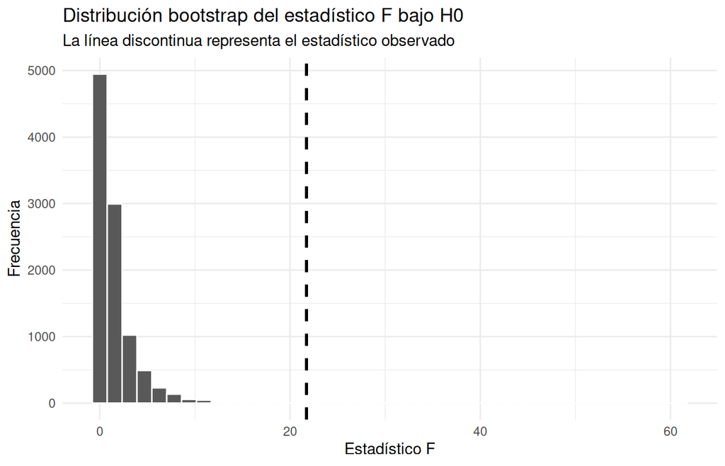

```r
ggplot(
  data.frame(F_boot = F_boot),
  aes(x = F_boot)
) +
  geom_histogram(bins = 40, color = "white") +
  geom_vline(
    xintercept = F_observado,
    linetype = "dashed",
    linewidth = 1
  ) +
  labs(
    title = "Distribución bootstrap del estadístico F bajo H0",
    subtitle = "La línea discontinua representa el estadístico observado",
    x = "Estadístico F",
    y = "Frecuencia"
  ) +
  theme_minimal()
```

# Análisis post-hoc

La prueba ómnibus permite determinar si existe alguna diferencia global, pero no identifica entre qué niveles ocurre. Por indicación del enunciado, se realiza el análisis post-hoc aunque la prueba global no resulte significativa.

Se comparan los tres pares de niveles usando las diferencias de medias obtenidas en las mismas remuestras bootstrap. Luego se aplica el ajuste de Holm, presentado en las lecturas, para controlar el aumento de errores de tipo I producido por las comparaciones múltiples.

```r
p_sin_ajustar <- sapply(
  seq_len(ncol(pares)),
  function(j) {
    (
      sum(
        abs(diferencias_boot[, j]) >=
          abs(diferencias_observadas[j])
      ) + 1
    ) / (B + 1)
  }
)

p_ajustados <- p.adjust(
  p_sin_ajustar,
  method = "holm"
)

resultados_posthoc <- data.frame(
  Grupo_1 = pares[1, ],
  Grupo_2 = pares[2, ],
  Diferencia_de_medias = diferencias_observadas,
  p_sin_ajustar = p_sin_ajustar,
  p_ajustado_Holm = p_ajustados,
  check.names = FALSE
)

resultados_posthoc_mostrar <- resultados_posthoc %>%
  mutate(
    Diferencia_de_medias = format(
      round(Diferencia_de_medias, 2),
      big.mark = ".",
      decimal.mark = ",",
      scientific = FALSE
    ),
    p_sin_ajustar = format.pval(
      p_sin_ajustar,
      digits = 4,
      eps = 0.0001
    ),
    p_ajustado_Holm = format.pval(
      p_ajustado_Holm,
      digits = 4,
      eps = 0.0001
    )
  )

knitr::kable(
  resultados_posthoc_mostrar,
  col.names = c(
    "Grupo 1",
    "Grupo 2",
    "Diferencia de medias (G1 - G2)",
    "p sin ajustar",
    "p ajustado por Holm"
  ),
  caption = "Comparaciones post-hoc"
)
```

Comparaciones post-hoc

| Grupo 1 | Grupo 2 | Diferencia de medias (G1 - G2) | p sin ajustar | p ajustado por Holm |
| --- | --- | --- | --- | --- |
| Básico o inferior | Medio | -329.813,7 | 4e-03 | 0.0040 |
| Básico o inferior | Superior | -1.524.372,9 | 1e-04 | 0.0003 |
| Medio | Superior | -1.194.559,2 | 6e-04 | 0.0012 |

# Conclusión

Con un nivel de significación del 5%, se rechaza la hipótesis nula de igualdad de medias. La muestra entrega evidencia de que al menos uno de los tres niveles educacionales presenta un ingreso total corregido promedio diferente (F = 21.732; p-valor bootstrap = 0.0014).

Las medias observadas en la muestra fueron:

Básico o inferior: $650.650. Medio: $980.464. Superior: $2.175.023. En el análisis post-hoc:

El grupo Medio presenta un ingreso promedio significativamente mayor que Básico o inferior (p ajustado = 0.004). El grupo Superior presenta un ingreso promedio significativamente mayor que Básico o inferior (p ajustado = 3e-04). El grupo Superior presenta un ingreso promedio significativamente mayor que Medio (p ajustado = 0.0012). Estos resultados muestran una asociación entre el nivel educacional de la persona adulta seleccionada y el ingreso del hogar. No permiten afirmar una relación causal, ya que los datos son observacionales y no se controlan otras características de las personas o de las viviendas.